# Transfer Learning with MobileNetV2 model

In this notebook, I am going to apply end-to-end transfer learning on EuroSat data with MobileNetV2 architecture.

Eurosat is a dataset and deep learning benchmark for land use and land cover classification. The dataset is based on Sentinel-2 satellite images covering 13 spectral bands and consisting out of 10 classes with in total 27,000 labeled and geo-referenced images. You can find out more details about dataset [here](https://github.com/phelber/eurosat)

## Table of content

- 1 - Packages
  - 1.1 Training and Validation Sets
- 2 - Data Augmentation
- 3 - Transfer Learning with MobileNet V2
- 4 - Fine Tuning of Model
- 5- Re-compiling with lower learning rate
- 6- References

## 1. Packages

```python
import matplotlib.pyplot as plt
import numpy as np
import itertools
import tensorflow as tf
from tensorflow import keras
from tensorflow.keras.preprocessing import image_dataset_from_directory
from tensorflow.keras.models import Model
from tensorflow.keras.layers.experimental.preprocessing import RandomFlip, RandomRotation
```

### 1.1 Training and Validation Sets

When training and evaluating deep learning models in Keras, generating a dataset from image files stored on disk is simple and fast. Call `image_data_set_from_directory()` to read from the directory and create both training and validation datasets.

You'll also set your seeds to match each other, so your training and validation sets don't overlap.

```python
directory = '2750'
batch_size = 32
image_size = (64,64)
```

```python
train_ds, val_ds = image_dataset_from_directory(directory,
                                               image_size=image_size,
                                               batch_size=batch_size,
                                                seed=101,
                                               shuffle =True,
                                               validation_split=0.2,
                                               subset="both")
```

```
Found 27000 files belonging to 10 classes.
Using 21600 files for training.
Using 5400 files for validation.
```

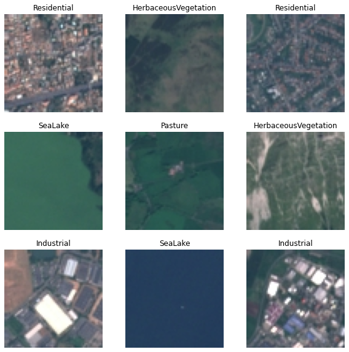

```python
class_names = train_ds.class_names

plt.figure(figsize=(10, 10))
for images, labels in train_ds.take(1):
    for i in range(9):
        ax = plt.subplot(3, 3, i + 1)
        plt.imshow(images[i].numpy().astype("uint8"))
        plt.title(class_names[labels[i]])
        plt.axis("off")
```

Using `prefetch()` prevents a memory bottleneck that can occur when reading from disk. It sets aside some data and keeps it ready for when it's needed, by creating a source dataset from your input data, applying a transformation to preprocess it, then iterating over the dataset one element at a time. Because the iteration is streaming, the data doesn't need to fit into memory.

```python
train_ds = train_ds.prefetch(buffer_size=tf.data.experimental.AUTOTUNE)
val_ds = val_ds.prefetch(buffer_size=tf.data.experimental.AUTOTUNE)
```

## 2. Data Augmentation

To increase diversity in the training set and help your model learn the data better, it's standard practice to augment the images by transforming them, i.e., randomly flipping and rotating them. Keras' Sequential API offers a straightforward method for these kinds of data augmentations, with built-in, customizable preprocessing layers. These layers are saved with the rest of your model and can be re-used later.

```python
def data_augmenter():

    data_augmentation = tf.keras.Sequential()
    data_augmentation.add(RandomFlip('horizontal'))
    data_augmentation.add(RandomRotation(0.2))

    return data_augmentation
```

## 3. Transfer Learning With MobileNet V2

- Depthwise separable convolutions
- Thin input and output bottlenecks between layers
- Shortcut connections between bottleneck layers

Key things to remember while using transfer learning:

1. Delete the top layer (the classification layer)
   - Set `include_top` in `base_model` as False
2. Add a new classifier layer
   - Train only one layer by freezing the rest of the network
3. Freeze the base model and train the newly-created classifier layer
   - Set `base model.trainable=False` to avoid changing the weights and train *only* the new layer
   - Set training in `base_model` to False to avoid keeping track of statistics in the batch norm layer

```python
def Euro_model(image_shape = image_size, classes = None, data_augmentation=data_augmenter()):
    input_shape = image_shape + (3,)

    base_model = tf.keras.applications.MobileNetV2(input_shape=input_shape,
                                                   include_top=False, # <== Important!!!!
                                                   weights="imagenet")
    base_model.trainable = False

    X_inputs = tf.keras.Input(shape=input_shape)
    X = tf.keras.layers.Rescaling(1.0/255)(X_inputs)
    X = data_augmentation(X)

    X= base_model(X, training = False)

    X = tf.keras.layers.AveragePooling2D((2, 2))(X)
    X = tf.keras.layers.Dropout(0.4)(X)
    X = tf.keras.layers.Flatten()(X)
    X = tf.keras.layers.Dense(classes, activation='softmax')(X)


    model = Model(inputs = X_inputs, outputs = X)

    return model
```

```python
model = Euro_model(image_size, 10)
```

```
WARNING:tensorflow:`input_shape` is undefined or non-square, or `rows` is not in [96, 128, 160, 192, 224]. Weights for input shape (224, 224) will be loaded as the default.
```

```python
model.summary()
```

```
Model: "model"
_________________________________________________________________
 Layer (type)                Output Shape              Param #
=================================================================
 input_2 (InputLayer)        [(None, 64, 64, 3)]       0

 rescaling (Rescaling)       (None, 64, 64, 3)         0

 sequential (Sequential)     (None, 64, 64, 3)         0

 mobilenetv2_1.00_224 (Funct  (None, 2, 2, 1280)       2257984
 ional)

 average_pooling2d (AverageP  (None, 1, 1, 1280)       0
 ooling2D)

 dropout (Dropout)           (None, 1, 1, 1280)        0

 flatten (Flatten)           (None, 1280)              0

 dense (Dense)               (None, 10)                12810

=================================================================
Total params: 2,270,794
Trainable params: 12,810
Non-trainable params: 2,257,984
_________________________________________________________________
```

```python
model.compile(optimizer=keras.optimizers.Adam(1e-3),loss="sparse_categorical_crossentropy",
               metrics=["sparse_categorical_accuracy"])
```

```python
epochs = 20
history = model.fit(train_ds,epochs=epochs,validation_data=val_ds)
```

[output not shown]

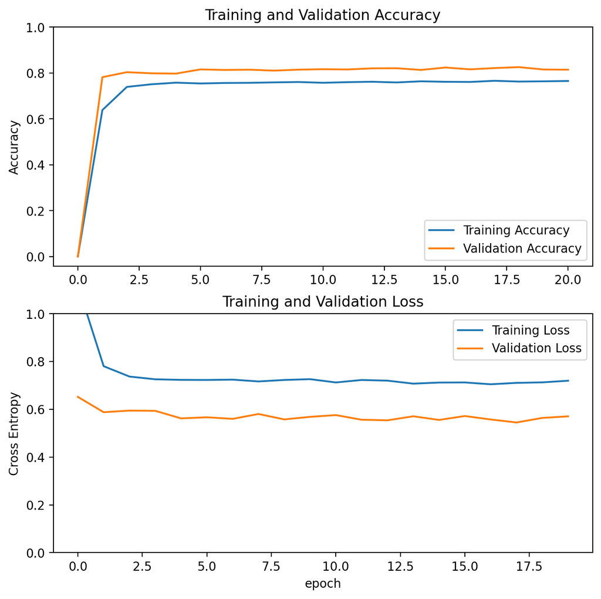

```python
acc = [0.] + history.history['sparse_categorical_accuracy']
val_acc = [0.] + history.history['val_sparse_categorical_accuracy']

loss = history.history['loss']
val_loss = history.history['val_loss']

plt.figure(figsize=(8, 8), dpi=200)
plt.subplot(2, 1, 1)
plt.plot(acc, label='Training Accuracy')
plt.plot(val_acc, label='Validation Accuracy')
plt.legend(loc='lower right')
plt.ylabel('Accuracy')
plt.ylim([min(plt.ylim()),1])
plt.title('Training and Validation Accuracy')

plt.subplot(2, 1, 2)
plt.plot(loss, label='Training Loss')
plt.plot(val_loss, label='Validation Loss')
plt.legend(loc='upper right')
plt.ylabel('Cross Entropy')
plt.ylim([0,1.0])
plt.title('Training and Validation Loss')
plt.xlabel('epoch')
plt.show()
```

With initial 20 epochs, the training accuracy and validation accuracy is 76.07% and 81.46% respectively, without any overfitting, but there is large avoidable bais ( as the original authors of paper has achieved 98% accuracy) which can be overcome by training the model for longer time and fine tuning the later layers.

## 4. Fine Tuning of Model

To achieve this, just unfreeze the final layers and re-run the optimizer with a smaller learning rate, while keeping all the other layers frozen. The important takeaway is that the later layers are the part of your network that contain the fine details that are more specific to problem.

First, unfreeze the base model by setting `base_model.trainable=True`, set a layer to fine-tune from, then re-freeze all the layers before it. Run it again for another few epochs, and see if accuracy improved!

```python
base_model = model.layers[3]
base_model.trainable = True

print("Number of layers in the base model: ", len(base_model.layers))
```

```
Number of layers in the base model:  154
```

```python
fine_tune_at = 110

for layer in base_model.layers[:fine_tune_at]:
    layer.trainable = None
```

```python
model.summary()
```

```
Model: "model"
_________________________________________________________________
 Layer (type)                Output Shape              Param #
=================================================================
 input_2 (InputLayer)        [(None, 64, 64, 3)]       0

 rescaling (Rescaling)       (None, 64, 64, 3)         0

 sequential (Sequential)     (None, 64, 64, 3)         0

 mobilenetv2_1.00_224 (Funct  (None, 2, 2, 1280)       2257984
 ional)

 average_pooling2d (AverageP  (None, 1, 1, 1280)       0
 ooling2D)

 dropout (Dropout)           (None, 1, 1, 1280)        0

 flatten (Flatten)           (None, 1280)              0

 dense (Dense)               (None, 10)                12810

=================================================================
Total params: 2,270,794
Trainable params: 1,755,978
Non-trainable params: 514,816
_________________________________________________________________
```

```python
model.compile(optimizer=keras.optimizers.Adam(1e-4),loss="sparse_categorical_crossentropy",
               metrics=["sparse_categorical_accuracy"])
```

```python
fine_tune_epochs = 10
total_epochs =  epochs + fine_tune_epochs

history_fine = model.fit(train_ds,
                         epochs=total_epochs,
                         initial_epoch=history.epoch[-1],
                         validation_data=val_ds)
```

[output not shown]

```python
acc += history_fine.history['sparse_categorical_accuracy']
val_acc += history_fine.history['val_sparse_categorical_accuracy']

loss += history_fine.history['loss']
val_loss += history_fine.history['val_loss']
```

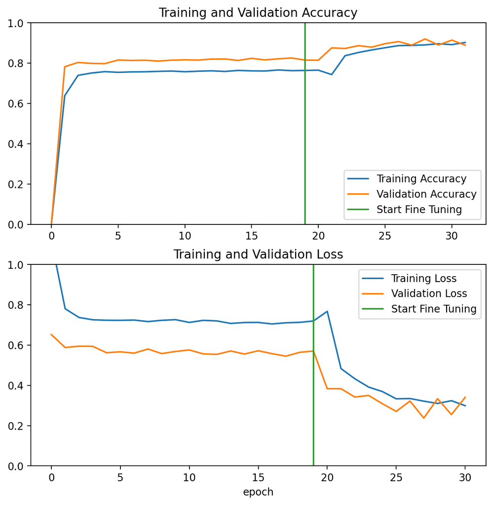

```python
plt.figure(figsize=(8, 8), dpi = 200)
plt.subplot(2, 1, 1)
plt.plot(acc, label='Training Accuracy')
plt.plot(val_acc, label='Validation Accuracy')
plt.ylim([0, 1])
plt.plot([epochs-1,epochs-1],
          plt.ylim(), label='Start Fine Tuning')
plt.legend(loc='lower right')
plt.title('Training and Validation Accuracy')

plt.subplot(2, 1, 2)
plt.plot(loss, label='Training Loss')
plt.plot(val_loss, label='Validation Loss')
plt.ylim([0, 1.0])
plt.plot([epochs-1,epochs-1],
         plt.ylim(), label='Start Fine Tuning')
plt.legend(loc='upper right')
plt.title('Training and Validation Loss')
plt.xlabel('epoch')
plt.show()
```

At 30 epochs after fine tuning and decreasing the learning, the training accuracy and validation accuracy is 90.28% and 88.94% respectively, with about 1.5% overfitting, but there is still avoidable bais which I will try to decrease by training model for more 10 epochs at same learing rate.

```python
fine_tune_epochs_2 = 10
total_epochs =  epochs + fine_tune_epochs + fine_tune_epochs_2

history_fine_2 = model.fit(train_ds,
                         epochs=total_epochs,
                         initial_epoch=history_fine.epoch[-1],
                         validation_data=val_ds)
```

```python
acc += history_fine_2.history['sparse_categorical_accuracy']
val_acc += history_fine_2.history['val_sparse_categorical_accuracy']

loss += history_fine_2.history['loss']
val_loss += history_fine_2.history['val_loss']
```

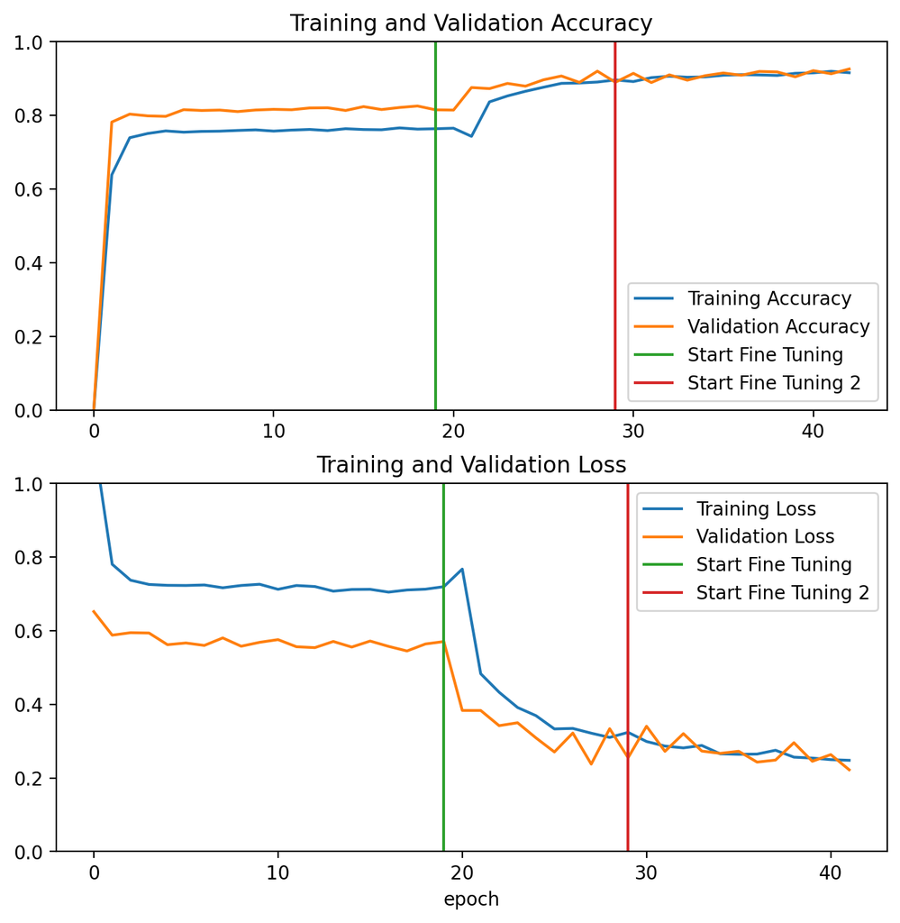

```python
plt.figure(figsize=(8, 8), dpi =200)
plt.subplot(2, 1, 1)
plt.plot(acc, label='Training Accuracy')
plt.plot(val_acc, label='Validation Accuracy')
plt.ylim([0, 1])
plt.plot([epochs-1,epochs-1],
          plt.ylim(), label='Start Fine Tuning')
plt.plot([epochs+fine_tune_epochs-1,epochs+fine_tune_epochs-1],
          plt.ylim(), label='Start Fine Tuning 2')
plt.legend(loc='lower right')
plt.title('Training and Validation Accuracy')

plt.subplot(2, 1, 2)
plt.plot(loss, label='Training Loss')
plt.plot(val_loss, label='Validation Loss')
plt.ylim([0, 1.0])
plt.plot([epochs-1,epochs-1],
          plt.ylim(), label='Start Fine Tuning')
plt.plot([epochs+fine_tune_epochs-1,epochs+fine_tune_epochs-1],
         plt.ylim(), label='Start Fine Tuning 2')
plt.legend(loc='upper right')
plt.title('Training and Validation Loss')
plt.xlabel('epoch')
plt.show()
```

The training accuracy and validation accuracy is 91.62% and 92.63% respectively after 40 epochs. Now the model is performing quide good with some avoidable bias and no overfitting on training data.

## 5. Re-compiling again with lower learning rate

```python
model.compile(optimizer=keras.optimizers.Adam(1e-5),loss="sparse_categorical_crossentropy",
               metrics=["sparse_categorical_accuracy"])
```

```python
fine_tune_epochs_3 = 20
total_epochs =  epochs + fine_tune_epochs + fine_tune_epochs_2 +fine_tune_epochs_3

history_fine_3 = model.fit(train_ds,
                         epochs=total_epochs,
                         initial_epoch=history_fine_2.epoch[-1],
                         validation_data=val_ds)
```

[output not shown]

```python
acc += history_fine_3.history['sparse_categorical_accuracy']
val_acc += history_fine_3.history['val_sparse_categorical_accuracy']

loss += history_fine_3.history['loss']
val_loss += history_fine_3.history['val_loss']
```

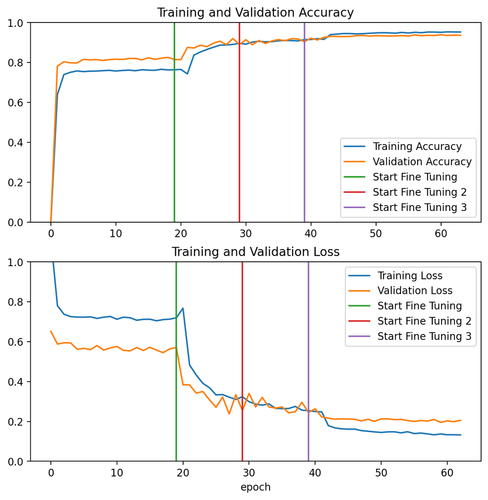

```python
plt.figure(figsize=(8, 8), dpi = 200)
plt.subplot(2, 1, 1)
plt.plot(acc, label='Training Accuracy')
plt.plot(val_acc, label='Validation Accuracy')
plt.ylim([0, 1])
plt.plot([epochs-1,epochs-1],
          plt.ylim(), label='Start Fine Tuning')
plt.plot([epochs+fine_tune_epochs-1,epochs+fine_tune_epochs-1],
          plt.ylim(), label='Start Fine Tuning 2')
plt.plot([total_epochs-fine_tune_epochs_3-1,total_epochs-fine_tune_epochs_3-1],
          plt.ylim(), label='Start Fine Tuning 3')
plt.legend(loc='lower right')
plt.title('Training and Validation Accuracy')

plt.subplot(2, 1, 2)
plt.plot(loss, label='Training Loss')
plt.plot(val_loss, label='Validation Loss')
plt.ylim([0, 1.0])
plt.plot([epochs-1,epochs-1],
          plt.ylim(), label='Start Fine Tuning')
plt.plot([epochs+fine_tune_epochs-1,epochs+fine_tune_epochs-1],
         plt.ylim(), label='Start Fine Tuning 2')
plt.plot([total_epochs-fine_tune_epochs_3-1,total_epochs-fine_tune_epochs_3-1],
          plt.ylim(), label='Start Fine Tuning 3')
plt.legend(loc='upper right')
plt.title('Training and Validation Loss')
plt.xlabel('epoch')
plt.show()
```

```python
model.save("Eurosat_MN_e50_d003_A.h5")
```

## 6. References

1. Eurosat: A novel dataset and deep learning benchmark for land use and land cover classification. Patrick Helber, Benjamin Bischke, Andreas Dengel, Damian Borth. IEEE Journal of Selected Topics in Applied Earth Observations and Remote Sensing, 2019.
2. Course 4 of Deep Learning Specialization by Andrew Ng

[Github profile](https://github.com/dineshgulati933)